# 新闻和推文分析

Kang

## 概述

主要任务：

- 将新闻文本转换成csv文件。
- 分析每年或每个月的新闻或推文数量变化。
- 对所有新闻文本进行主题分析，解读出文本涉及的若干主题。
- 对新闻文本进行情感分析。
- 对部分推文文本进行主题分析。

## 数量变化

新闻每个月数量变化如下。

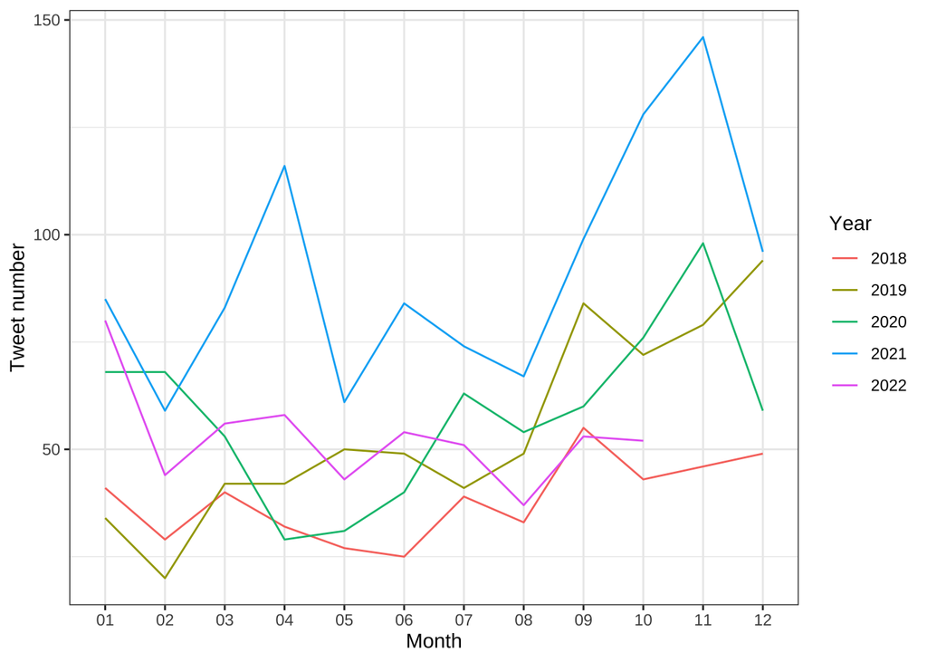

```r
# 每个月新闻数量变化。
ash %>%
  group_by(year, month) %>%
  summarise(n = n(), .groups = "drop") %>%
  ggplot() +
  geom_line(aes(month, n, col = year, group = year)) +
  labs(x = "Month", y = "Tweet number", col = "Year") +
  theme_bw()
```

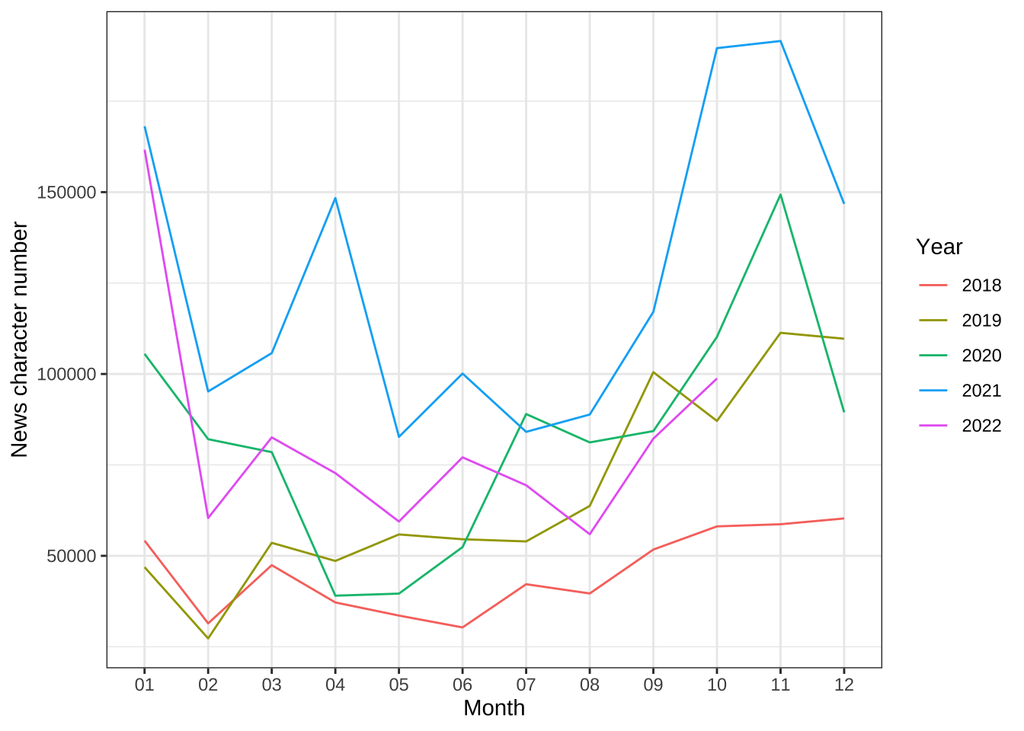

```r
# 每个月字数变化。
ash %>%
  group_by(year, month) %>%
  summarise(char_count = sum(char_count), .groups = "drop") %>%
  ggplot() +
  geom_line(aes(month, char_count, col = year, group = year)) +
  labs(x = "Month", y = "News character number", col = "Year") +
  theme_bw()
```

推文每月数量变化：

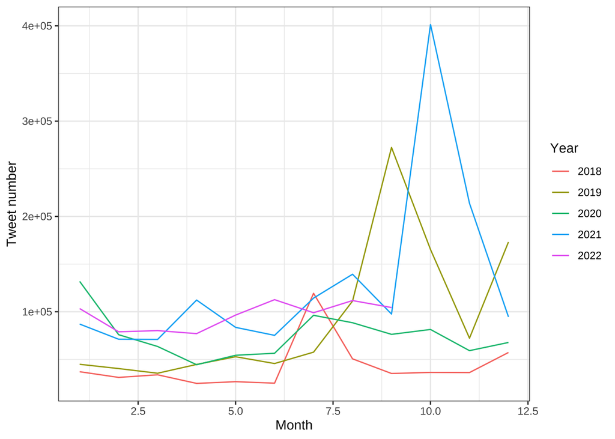

```r
general_plot_dt %>%
  mutate(year = year(date), month = month(date)) %>%
  group_by(year, month) %>%
  summarise(tw_num = sum(tw_num), .groups = "drop") %>%
  ggplot() +
  geom_line(aes(month, tw_num, col = as.character(year), group = year)) +
  labs(x = "Month", y = "Tweet number", col = "Year") +
  theme_bw()
```

推文数量和新闻每月字数之间正相关：

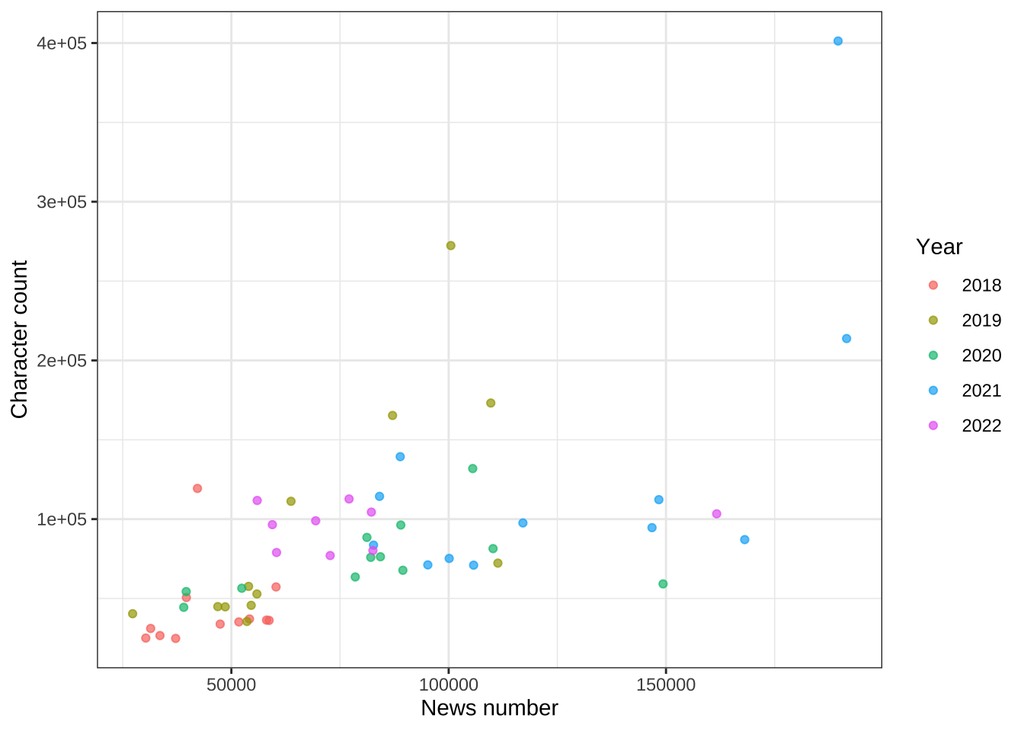

```r
mth_twnum_newschar %>%
  ggplot() +
  geom_point(aes(char_count, tw_num, col = as.character(year)), alpha = 0.7) +
  labs(x = "News number", y = "Character count", col = "Year") +
  theme_bw()
```

```r
cor.test(mth_twnum_newschar$tw_num, mth_twnum_newschar$char_count)
```

```
##
##  Pearson's product-moment correlation
##
## data:  mth_twnum_newschar$tw_num and mth_twnum_newschar$char_count
## t = 6.0107, df = 55, p-value = 1.546e-07
## alternative hypothesis: true correlation is not equal to 0
## 95 percent confidence interval:
##  0.4415147 0.7647448
## sample estimates:
##       cor
## 0.6296452
```

推文条数和新闻篇数相关：

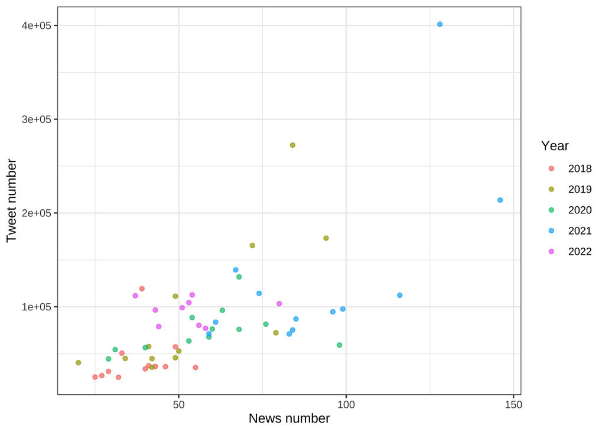

```r
mth_twnum_newsnum %>%
  ggplot() +
  geom_point(aes(news_num, tw_num, col = as.character(year)), alpha = 0.7) +
  labs(x = "News number", y = "Tweet number", col = "Year") +
  theme_bw()
```

```r
cor.test(mth_twnum_newsnum$tw_num, mth_twnum_newsnum$news_num)
```

```
##
##  Pearson's product-moment correlation
##
## data:  mth_twnum_newsnum$tw_num and mth_twnum_newsnum$news_num
## t = 6.7531, df = 55, p-value = 9.567e-09
## alternative hypothesis: true correlation is not equal to 0
## 95 percent confidence interval:
##  0.5005220 0.7944702
## sample estimates:
##       cor
## 0.6732805
```

## 主题分析

文本分析的基本流程为：

（1）先读取所有新闻（我们称每条新闻为”文档”）。

（2）将每个文档进行分词。

（3）去除停止词。

（4）统计词语的频率，同时也可以计算词语的重要性（TF-IDF方法）。

（5）用主题模型对各个文档进行归类，结果呈现为每个文档被划分到各个主题的概率，例如，如果我们希望所有文档被归入3个主题中，那么某个文档属于主题1、2、3的概率可能分别是0.8、0.1、0.1。

用LDA方法对文本进行主题分析，需要先定义主题数量。如果主题数量很少，例如极端情况下（理论上并不合理），我们将所有文档只归入1个主题中，那么所有文档属于该主题的概率就是100%，这种主题划分就没有意义了；再往前一步，如果分成2个主题，如果文档之间有很好的区分度，那没有问题，但是也可能出现大部分文档归入两个主题的概率都差不多是50%，区分度不够高；反之，如果我们将n个文档归入将近n个主题，那每个文档肯定会有所属概率更高的主题类别，但是主题太多，归类的意义也就小了。因此，在定义主题数量的时候，我们希望尽量少，但是又有足够的区分度。

```r
# 图形参考之前的报告。
```

```r
# 图形参考之前的报告。
```

```r
library(knitr)
library(kableExtra)
topic_word %>%
  kable() %>%
  kable_styling()
```

| topic | term |
| --- | --- |
| 1 | 研究, 地球, 真鍋, 化, 日本, 温暖, 自然, 気候, 環境, 人, 世界, 気象, 受賞, 大, 的, 科学, ノーベル, 生物, 賞, 人間, 影響, 性, 者, 変動, 物理, 予測, 教授, 大気, きた, 多様 \| |
| 2 | 的, 氏, 党, 経済, 政策, 首相, 社会, 化, 人, コロナ, 問題, 選挙, 政権, 者, 国民, 対策, 日本, 成長, 支援, 政治, 国, 危機, 実現, 対応, 進, デジタル, 選, 強化, 円, 課題 \| |
| 3 | 人, 大, 賞, 東京, 的, 歳, たち, 社会, 若者, 日本, 政治, 者, 投票, 選挙, 目, 作品, 選, 見, コロナ, きた, 県, 回, 気候, 氏, 女性, 活動, 感じ, 写真, 課題, 企画 \| |
| 4 | 市, 人, 県, 約, 環境, 的, 食, 化, 者, きた, 肉, 見, たち, 性, 食品, 菜食, 東京, ビーガン, 目, ほど, 水, 地球, 大, 出, 会, 町, なり, 農業, 研究, 被害 \| |
| 5 | 米, 中国, 氏, ン, 米国, 国, デ, 的, バイ, 政権, 気候, 変動, 日本, 大統領, 問題, 世界, 首脳, 関係, 会議, 会談, コロナ, 首相, 経済, 協力, 者, 台湾, 国際, 大, 習, 外交 \| |
| 6 | 国, 目標, 排出, 日本, 気候, 的, ガス, 企業, 化, 世界, 削減, 対策, 変動, 石炭, 効果, 度, 量, 約, 温室, エネルギー, 脱, 政府, 炭素, 環境, ゼ, ロ, 車, 連, 投資, 自動車 \| |

选取各主题典型文本：

```r
topic_text %>%
  kable() %>%
  kable_styling()
```

[output not shown]

计算各个主题的显著度，所要求时间段（和下面推文主题分析的时间一致）各主题显著度随着时间变化如下：

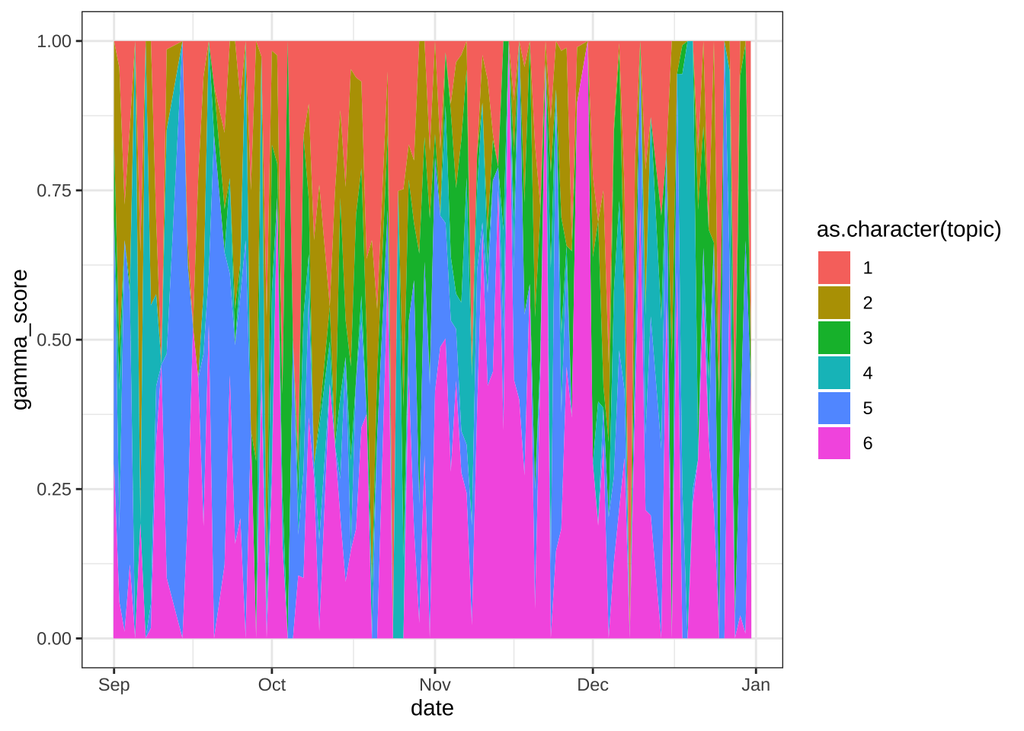

```r
quan_id_topic %>%
  mutate(
    year = substr(date, 1, 4),
    month = substr(date, 6, 7) %>% as.numeric(),
    day = substr(date, 9, 10),
    date = as_date(paste(year, month, day, sep = "-"))
  ) %>%
  group_by(date, topic) %>%
  summarise(gamma = sum(gamma), .groups = "drop") %>%
  group_by(date) %>%
  mutate(tot_gamma = sum(gamma), gamma_score = gamma / tot_gamma) %>%
  ggplot() +
  geom_area(aes(date, gamma_score, fill = as.character(topic))) +
  theme_bw()
```

同样地，对推文进行主题分析。对于所要求时间段，每个月份1000条推文进行分析。同样拆分成6个主题。

```r
topic_word_2021 %>%
  kable() %>%
  kable_styling()
```

| topic | term |
| --- | --- |
| 1 | 地球温暖化, 石炭, 温暖化, 中国, 影響, ノーベル, 真鍋, 電力, 豪, 停電, 不足, 物理, 原発, 計画, 米, 予測, 学賞, 今日, 大, なぁ, したら, 干ばつ, 流れ, 淑郎, 停止, 作, 日本, 汚染, 大幅, 半分, 氏, 工場, バレ, 書き換え, 値上げ, リンク, 直前, 売, 騒ぎ, 火力発電, 操業, クリック, 大騒ぎ, 穀物, 伸びる, 悪用, ニュース… |
| 2 | 温暖化, 地球温暖化, 地球, 問題, 環境, 的, 関係, 行, 世界, 活動, 日本, 対策, 寒冷化, 人, 思, 人間, 二酸化炭素, グレタ, 家, 今, きた, 話, 方, 良い, 化, 影響, 気候変動, 進, 起, 必要, 報告, 気温, 宇宙, 自然, レジ袋, なん, 人類, 太陽, 学校, あまり, 性, 相, 共有, 社会, 解説, できる, なんて, 実感, 考え, 温度… |
| 3 | 温暖化, 北海道, 米, おかげ, 発言, コメ, 葉, うまく, 農家, 麻生太郎, 麻生氏, 総裁, 美味, 自民党, 副, 麻生, 民, 人, 期間, 自, 美しい, 販売, 柿, すし, 言, 農業, 県, 見, 努力, 市, 道, 影響, くる, 氏, ところ, 者, 朝日新聞, 秋, うまい, コロナ, デジタル, 地元, 選挙, 選, 昔, 手, 短, 首相, 紅葉, 院, 品種改良… |
| 4 | 温暖化, 対策, 地球温暖化, 日本, 気候変動, どう, 大人, 炭素, 地球, 新聞, アクション, 考える, できる, 脱, 環境, 世界, 的, 事, 知, これから, 歳, 責任, ロ, ヤバ, まとめ, 今, 生活, 起, 個人, 毎日, 原因, 大, 乗り, 国, 効果, ー, いま, 活動, 越, 作り, 訴え, 報告書, ゼ, 若者, 嬉しい, 正直, 化, 放棄, 絶望, さい… |
| 5 | 温暖化, 地球温暖化, 日本, 世界, 賞, 的, 影響, 国, 地球, 台風, コード, 化石, 環境, 対策, 原因, 剤, 研究, 嘘, 考え, 削減, 海, 人類, 最大, 上昇, 今, なり, 大気, 氷, 事, 人, 危機, 風, 中国, さい, アース, 続, ニュース, 勢力, 脅威, 自動車, 警告, よね, 記事, 化, 国際, くだ, 二酸化炭素, 猛烈, 今後, 南極, 異… |
| 6 | 温暖化, 地球温暖化, 対策, 言, 原発, 発電, 日本, 炭素, 国, ガス, 防止, エネルギー, 危機, 脱, 政権, グレタ, 気候, 党, 人, 原子力, われ, チン, プー, 進, 騙, 詐欺, 的, 太陽光, 話, 氏, くらい, 税, 大, いい, 共産, 日本人, 暴露, コロナ, 事, 推進, 出, 発言, 批判, 石油, 必要, 政治, 熊本, 産業, 法, 寒い, ー,… |

推文各个主题的显著度变化：

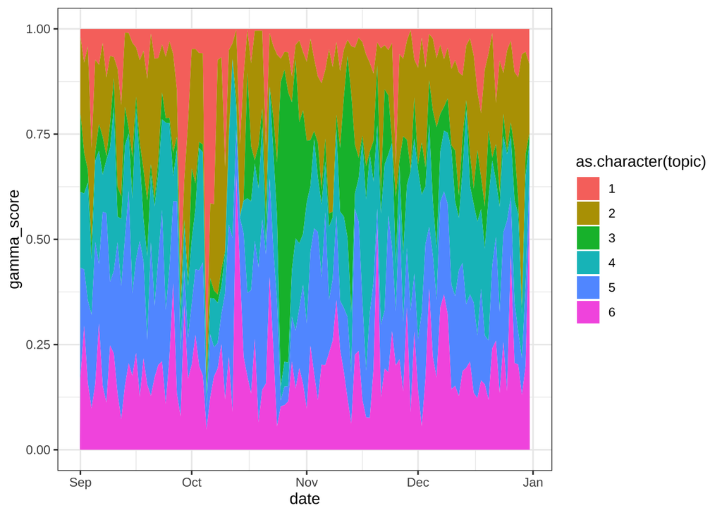

```r
tw_id_topic %>%
  group_by(date, topic) %>%
  summarise(gamma = sum(gamma), .groups = "drop") %>%
  group_by(date) %>%
  mutate(tot_gamma = sum(gamma), gamma_score = gamma / tot_gamma) %>%
  ggplot() +
  geom_area(aes(date, gamma_score, fill = as.character(topic))) + theme_bw()
```

## 情感分析

新闻情感分析结果中，各个词语的极性如下。

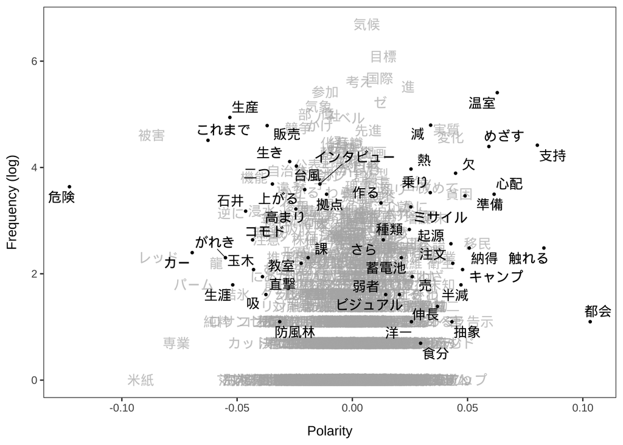

```r
textplot_terms(lss)
```

新闻情感随着时间的变化如下：

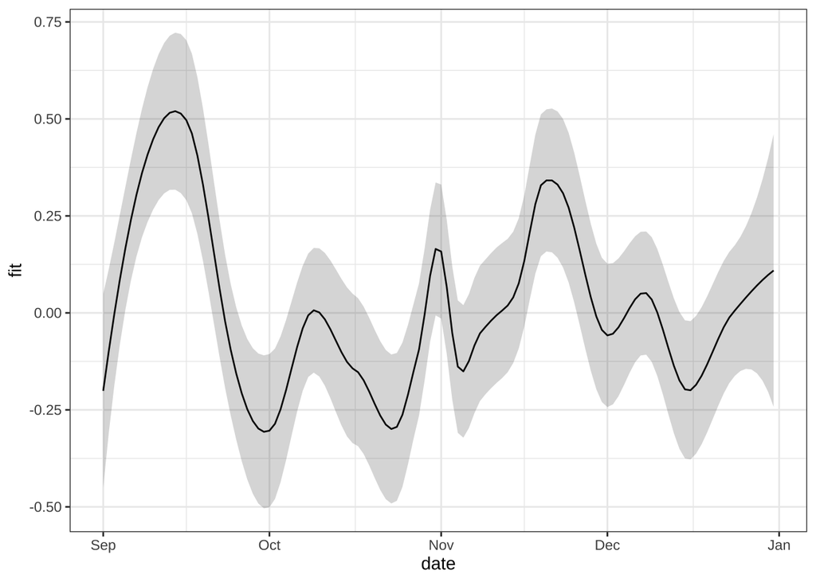

```r
ggplot(lss_score_smooth) +
  geom_line(aes(date, fit)) +
  geom_ribbon(aes(x = date, ymin = fit - se, ymax = fit + se), alpha = 0.2) +
  theme_bw()
```

**推文的情感分析明天看时间吧。**

## 新闻-推文相互影响

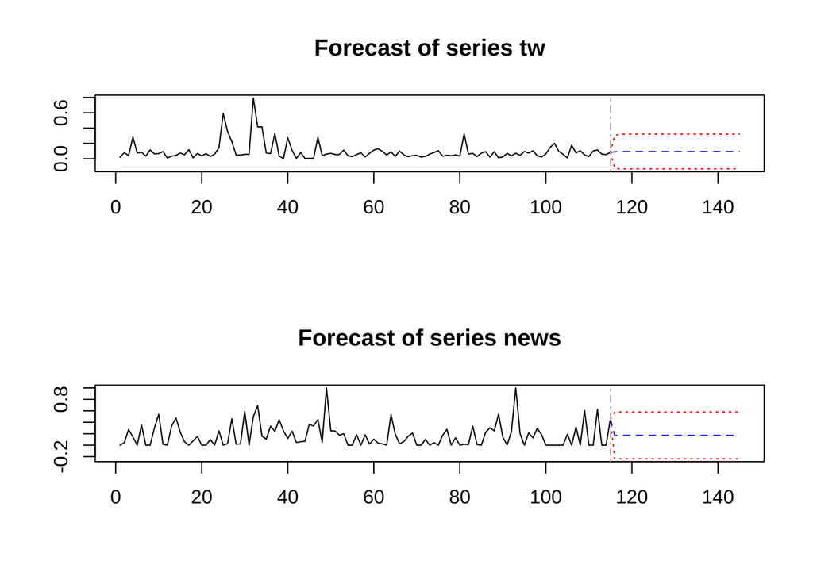

```
##
## VAR Estimation Results:
## =========================
## Endogenous variables: tw, news
## Deterministic variables: const
## Sample size: 114
## Log Likelihood: 111.439
## Roots of the characteristic polynomial:
## 0.3308 0.0005577
## Call:
## VAR(y = data_sub, p = lag_selection$selection[1], type = "const")
##
##
## Estimation results for equation tw:
## ===================================
## tw = tw.l1 + news.l1 + const
##
##          Estimate Std. Error t value Pr(>|t|)
## tw.l1    0.331493   0.089933   3.686 0.000354 ***
## news.l1 -0.001323   0.050082  -0.026 0.978971
## const    0.063136   0.015138   4.171 6.05e-05 ***
## ---
## Signif. codes:  0 '***' 0.001 '**' 0.01 '*' 0.05 '.' 0.1 ' ' 1
##
##
## Residual standard error: 0.109 on 111 degrees of freedom
## Multiple R-Squared: 0.1101,  Adjusted R-squared: 0.0941
## F-statistic: 6.869 on 2 and 111 DF,  p-value: 0.00154
##
##
## Estimation results for equation news:
## =====================================
## news = tw.l1 + news.l1 + const
##
##           Estimate Std. Error t value Pr(>|t|)
## tw.l1    0.1828464  0.1716073   1.065    0.289
## news.l1 -0.0001733  0.0955642  -0.002    0.999
## const    0.1543351  0.0288859   5.343 4.93e-07 ***
## ---
## Signif. codes:  0 '***' 0.001 '**' 0.01 '*' 0.05 '.' 0.1 ' ' 1
##
##
## Residual standard error: 0.2081 on 111 degrees of freedom
## Multiple R-Squared: 0.01025, Adjusted R-squared: -0.007586
## F-statistic: 0.5746 on 2 and 111 DF,  p-value: 0.5646
##
##
##
## Covariance matrix of residuals:
##            tw     news
## tw   0.011892 0.001741
## news 0.001741 0.043298
##
## Correlation matrix of residuals:
##           tw    news
## tw   1.00000 0.07672
## news 0.07672 1.00000
```

```r
# 函数的输入变量中，前者为新闻主题编号，后者为推文主题编号。
get_var_res(1, 1)
```

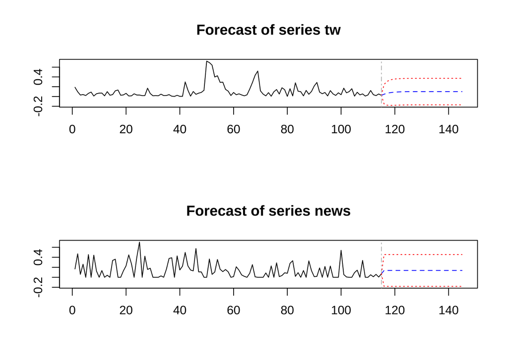

```
##
## VAR Estimation Results:
## =========================
## Endogenous variables: tw, news
## Deterministic variables: const
## Sample size: 114
## Log Likelihood: 147.398
## Roots of the characteristic polynomial:
## 0.6774 0.00148
## Call:
## VAR(y = data_sub, p = lag_selection$selection[1], type = "const")
##
##
## Estimation results for equation tw:
## ===================================
## tw = tw.l1 + news.l1 + const
##
##         Estimate Std. Error t value Pr(>|t|)
## tw.l1    0.67745    0.06986   9.698   <2e-16 ***
## news.l1  0.01344    0.05960   0.226   0.8220
## const    0.03049    0.01465   2.081   0.0397 *
## ---
## Signif. codes:  0 '***' 0.001 '**' 0.01 '*' 0.05 '.' 0.1 ' ' 1
##
##
## Residual standard error: 0.1018 on 111 degrees of freedom
## Multiple R-Squared: 0.4587,  Adjusted R-squared: 0.4489
## F-statistic: 47.03 on 2 and 111 DF,  p-value: 1.611e-15
##
##
## Estimation results for equation news:
## =====================================
## news = tw.l1 + news.l1 + const
##
##          Estimate Std. Error t value Pr(>|t|)
## tw.l1   -0.003226   0.111368  -0.029    0.977
## news.l1 -0.001543   0.095011  -0.016    0.987
## const    0.136908   0.023356   5.862 4.78e-08 ***
## ---
## Signif. codes:  0 '***' 0.001 '**' 0.01 '*' 0.05 '.' 0.1 ' ' 1
##
##
## Residual standard error: 0.1623 on 111 degrees of freedom
## Multiple R-Squared: 9.706e-06,   Adjusted R-squared: -0.01801
## F-statistic: 0.0005387 on 2 and 111 DF,  p-value: 0.9995
##
##
##
## Covariance matrix of residuals:
##              tw       news
## tw    0.0103580 -0.0005648
## news -0.0005648  0.0263262
##
## Correlation matrix of residuals:
##           tw    news
## tw    1.0000 -0.0342
## news -0.0342  1.0000
```

```r
get_var_res(2, 3)
```

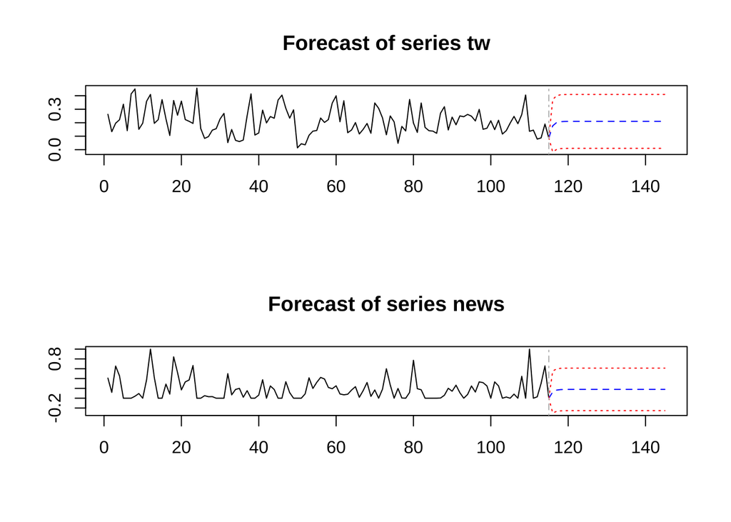

```
##
## VAR Estimation Results:
## =========================
## Endogenous variables: tw, news
## Deterministic variables: const
## Sample size: 114
## Log Likelihood: 117.153
## Roots of the characteristic polynomial:
## 0.2733 0.0828
## Call:
## VAR(y = data_sub, p = lag_selection$selection[1], type = "const")
##
##
## Estimation results for equation tw:
## ===================================
## tw = tw.l1 + news.l1 + const
##
##         Estimate Std. Error t value Pr(>|t|)
## tw.l1    0.22936    0.09284   2.470    0.015 *
## news.l1  0.02576    0.04248   0.607    0.545
## const    0.15719    0.02279   6.898 3.41e-10 ***
## ---
## Signif. codes:  0 '***' 0.001 '**' 0.01 '*' 0.05 '.' 0.1 ' ' 1
##
##
## Residual standard error: 0.09893 on 111 degrees of freedom
## Multiple R-Squared: 0.05646, Adjusted R-squared: 0.03946
## F-statistic: 3.321 on 2 and 111 DF,  p-value: 0.03973
##
##
## Estimation results for equation news:
## =====================================
## news = tw.l1 + news.l1 + const
##
##         Estimate Std. Error t value Pr(>|t|)
## tw.l1    0.24989    0.20417   1.224   0.2236
## news.l1  0.12673    0.09341   1.357   0.1777
## const    0.10450    0.05011   2.085   0.0393 *
## ---
## Signif. codes:  0 '***' 0.001 '**' 0.01 '*' 0.05 '.' 0.1 ' ' 1
##
##
## Residual standard error: 0.2176 on 111 degrees of freedom
## Multiple R-Squared: 0.03072, Adjusted R-squared: 0.01326
## F-statistic: 1.759 on 2 and 111 DF,  p-value: 0.177
##
##
##
## Covariance matrix of residuals:
##             tw      news
## tw   0.0097871 0.0004644
## news 0.0004644 0.0473318
##
## Correlation matrix of residuals:
##           tw    news
## tw   1.00000 0.02158
## news 0.02158 1.00000
```

```r
get_var_res(5, 5)
```

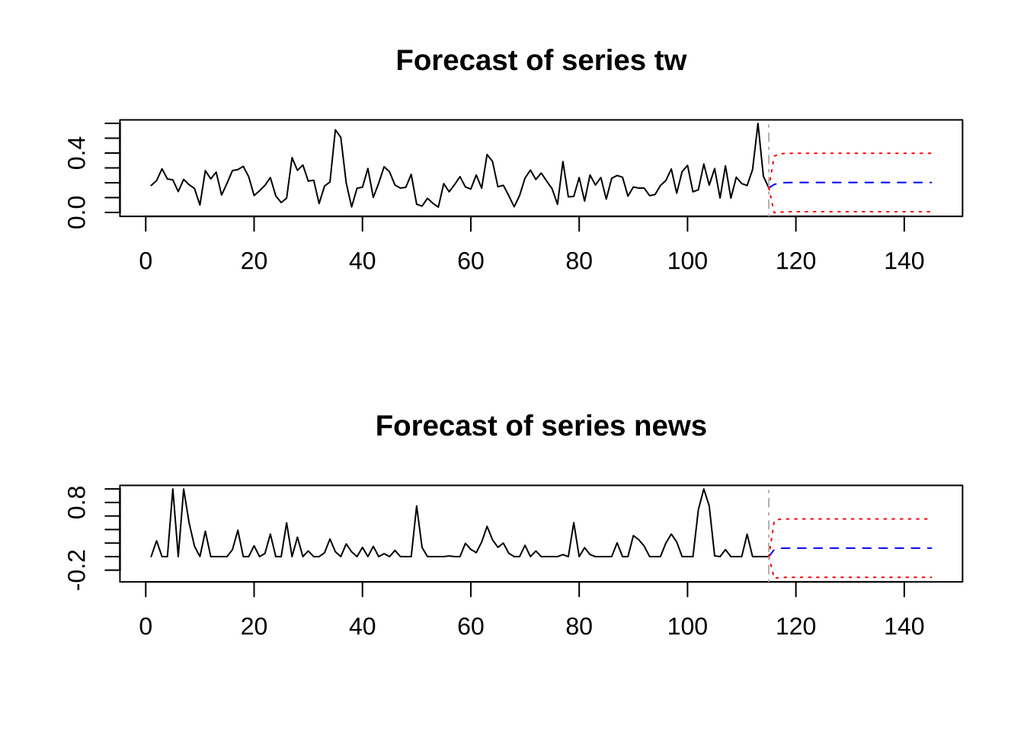

```
##
## VAR Estimation Results:
## =========================
## Endogenous variables: tw, news
## Deterministic variables: const
## Sample size: 114
## Log Likelihood: 119.684
## Roots of the characteristic polynomial:
## 0.2069 0.2069
## Call:
## VAR(y = data_sub, p = lag_selection$selection[1], type = "const")
##
##
## Estimation results for equation tw:
## ===================================
## tw = tw.l1 + news.l1 + const
##
##         Estimate Std. Error t value Pr(>|t|)
## tw.l1    0.21779    0.09223   2.361   0.0199 *
## news.l1  0.04262    0.04203   1.014   0.3128
## const    0.15243    0.02129   7.159 9.34e-11 ***
## ---
## Signif. codes:  0 '***' 0.001 '**' 0.01 '*' 0.05 '.' 0.1 ' ' 1
##
##
## Residual standard error: 0.09742 on 111 degrees of freedom
## Multiple R-Squared: 0.05705, Adjusted R-squared: 0.04006
## F-statistic: 3.358 on 2 and 111 DF,  p-value: 0.03838
##
##
## Estimation results for equation news:
## =====================================
## news = tw.l1 + news.l1 + const
##
##         Estimate Std. Error t value Pr(>|t|)
## tw.l1   -0.03496    0.20453  -0.171   0.8646
## news.l1  0.18975    0.09321   2.036   0.0442 *
## const    0.10872    0.04722   2.303   0.0232 *
## ---
## Signif. codes:  0 '***' 0.001 '**' 0.01 '*' 0.05 '.' 0.1 ' ' 1
##
##
## Residual standard error: 0.216 on 111 degrees of freedom
## Multiple R-Squared: 0.03612, Adjusted R-squared: 0.01876
## F-statistic:  2.08 on 2 and 111 DF,  p-value: 0.1298
##
##
##
## Covariance matrix of residuals:
##             tw      news
## tw   0.0094904 0.0001802
## news 0.0001802 0.0466728
##
## Correlation matrix of residuals:
##            tw     news
## tw   1.000000 0.008563
## news 0.008563 1.000000
```

```r
get_var_res(4, 2)
```